# Alien analysis & workshop notes

Ian Handel

11/04/2018

## Introduction

Here’s the tidied up notes from the ‘alien-analysis session’. This document was made by ‘knitting’ an RMarkdown file which loads in the alien data from an Excel workbook (in the same folder), cleans it and then analyses it. The RMarkdown file is very similar to the one you will have made in the workshop. We’ve added some lines to the header to make a table of contents and to change the colour scheme. There’s also more text added to explain what’s going on. Finally we’ve added some further code to demonstrate more features of R including data management, plotting and some basic statistics. When you’re reading through these notes you can also look at the `alien_analysis_20180404.Rmd` RMarkdown file to see the code that made it.

We’ll include web links to Hadley Wickham and Garrett Grolemund’s excellent R for Data Science book [R4DS](http://r4ds.had.co.nz) and other sources with more detail where relevant.

R code is shown in these notes in boxes with a light grey background. R output is shown in boxes with a white background with ‘##’ at the left hand side of each line.

## Load Packages

First job is to load the add-in packages that we’ll need. When you load packages there’ll normally be quite a few warnings and messages.

```r
#load libraries
library(tidyverse)
library(readxl)
library(skimr)
library(knitr)
```

## Get data in

```r
alien <- read_excel("aliendata_20180404.xlsx", sheet = 1, na = "-999")
```

Once the data is in R we can look at the top of it by clicking on its name in the “environment” tab/panel (top right part of the RSTudio window) or by typing `View(alien)` into the console (note that “View”" has a capital “V”). Once we’ve had a look we can start cleaning and tidying it ready for analysis.

## Data tidy and clean

### Fill missing regions

First thing to do is to fill down the missing cells in the “region” column. The following R code takes the `alien` object, pipes it into the `fill` function/verb and fills the “region” column. The result is put back into the `alien` object with `<-`. Remember, this changes the `alien` object in R but doesn’t alter the spreadsheet. This is important. It means our original data is untouched and is always available if we change out minds about our tidying!

If you want to look at what the code is doing one step at a time you can run each code chunk in the `alien_analysis_20180404.Rmd` file at a time (using the little green arrow at its right hand side) and keep looking back at the `alien` data to see it change.

```r
alien <- alien %>%
  fill(region)
```

### Remove names

Next we’ll remove the alien names - it’s personal data that we don’t need and would rather not have on our screens (aliens have rights too!). The `select()` verb/function lets us do this. If we give it column names either one at a time or in a range with ‘:’ between them it will *keep* those columns. If we put a “-” infront of one or more column names it will remove them. See [R4DS](http://r4ds.had.co.nz/transform.html#select-columns-with-select) for more detailed instructions on using `select()`.

```r
alien <- alien %>%
  select(-name)
```

### Improve the subject iD format

Teh subject ID is currebtly a number. Wwe prefer ID’s to be formatted so thay are unambiguously an ‘ID’ and to be the same number of charcters long. We use a new verb/function here `mutate`. You pipe a data frame into mutate and give it the name of the column you want to create then `=` and then an expression (recispe) for the column. If you create an existing column it effectively overwirites it. So first off we overwrite subject using the str_pad function (this function is in the “stringr”)

Tidy ID column

```r
alien <- alien %>%
  mutate(subject = str_pad(subject, width = 3, side = "left", pad = "0")) %>%
  mutate(subject = str_c("A", subject))
```

Separate type column

```r
alien <- alien %>%
  separate(type, into = c("sex", "colour"), sep = "_")
```

Take the first letter of sex column and correct colour column

```r
library(stringr)
alien <- alien %>%
  mutate(sex = str_sub(sex, start = 1, end = 1)) %>%
  mutate(colour = str_to_lower(colour))
```

Rename columns

```r
alien <- alien %>%
  rename(glucose = "glucose - mg/L",
         iq = "IQ - ref to human 100 scale!")
```

## Data exploration

Quick look

```r
skim(alien)
```

```
## Skim summary statistics
##  n obs: 200
##  n variables: 11
##
## Variable type: character
##  variable missing complete   n min max empty n_unique
##    colour       0      200 200   3   6     0        4
##    drives       0      200 200   2  22     0       38
##    health       0      200 200   6  15     0        4
##    region       0      200 200   8   9     0        4
##       sex       0      200 200   1   1     0        2
##   subject       0      200 200   4   4     0      200
##
## Variable type: numeric
##  variable missing complete   n   mean     sd     p0    p25 median    p75
##       age       0      200 200  22.77  16.37   0.3   11.05  19.02  30.2
##   glucose       0      200 200  15.48   3.05   8.37  13.34  15.03  17.09
##        iq       0      200 200 570.45 140.71 284    480.75 545    641
##      iron      19      181 200  28.14   5.23  12     24.4   28.5   31.3
##    weight       0      200 200 101.14  15.84  59.14  90.03 100.73 111.51
##     p100     hist
##    80.81 ▆▇▅▃▁▁▁▁
##    26.36 ▁▅▇▇▃▂▁▁
##  1126    ▂▅▇▃▂▁▁▁
##    41.5  ▁▁▃▇▇▇▂▁
##   138.27 ▁▂▅▇▇▆▃▂
```

Tabulations

```r
alien %>%
  count(colour, sex)
```

```
## # A tibble: 8 x 3
##   colour sex       n
##   <chr>  <chr> <int>
## 1 green  f        37
## 2 green  m        26
## 3 orange f        11
## 4 orange m        13
## 5 purple f        52
## 6 purple m        53
## 7 red    f         6
## 8 red    m         2
```

Sort colours in order of popularity

```r
alien %>%
  count(colour, sort = TRUE)
```

```
## # A tibble: 4 x 2
##   colour     n
##   <chr>  <int>
## 1 purple   105
## 2 green     63
## 3 orange    24
## 4 red        8
```

Sort by age

```r
alien %>%
  arrange(desc(age))
```

```
## # A tibble: 200 x 11
##    region  subject sex   colour drives     age health  glucose  iron    iq
##    <chr>   <chr>   <chr> <chr>  <chr>    <dbl> <chr>     <dbl> <dbl> <dbl>
##  1 Northl… A038    f     purple F150 Pi…  80.8 slight…    19.4  41.5  1126
##  2 Westla… A089    f     orange Gti       75.9 very s…    24.7  34.1  1011
##  3 Westla… A122    f     purple Grand C…  73.8 slight…    19.9  30.0   949
##  4 Southl… A151    m     green  Durango…  73.7 very s…    26.4  30.9   957
##  5 Eastla… A044    m     green  Altima    70.3 slight…    22.8  24.0   857
##  6 Eastla… A146    m     green  A4 Quat…  65.9 very s…    22.7  28.9   872
##  7 Southl… A053    m     purple F150 Pi…  63.5 very s…    23.0  38.6   972
##  8 Northl… A056    f     purple Malibu    62.3 spotty     20.5  33.8   897
##  9 Northl… A073    m     purple A6 Quat…  61.9 slight…    17.8  NA     845
## 10 Westla… A029    f     purple Grand C…  60.2 very s…    20.4  35.6   913
## # ... with 190 more rows, and 1 more variable: weight <dbl>
```

Filter dataframe by male green older than 8

```r
alien %>%
  filter(sex == "m", age > 8, colour == "green")
```

```
## # A tibble: 26 x 11
##    region  subject sex   colour drives     age health  glucose  iron    iq
##    <chr>   <chr>   <chr> <chr>  <chr>    <dbl> <chr>     <dbl> <dbl> <dbl>
##  1 Eastla… A119    m     green  A4 Quat… 15.0  slight…    16.5  21.7   447
##  2 Eastla… A189    m     green  A4 Quat… 35.3  healthy    17.8  NA     673
##  3 Eastla… A083    m     green  Toyota … 18.6  slight…    17.8  26.8   521
##  4 Eastla… A146    m     green  A4 Quat… 65.9  very s…    22.7  28.9   872
##  5 Eastla… A044    m     green  Altima   70.3  slight…    22.8  24.0   857
##  6 Eastla… A130    m     green  Corvette 12.8  healthy    14.4  23.8   454
##  7 Eastla… A071    m     green  Grand P… 13.4  slight…    17.7  25.5   466
##  8 Northl… A147    m     green  Navigat… 35.2  slight…    20.8  24.6   614
##  9 Northl… A144    m     green  4Runner…  8.32 slight…    16.3  27.2   465
## 10 Northl… A134    m     green  K1500 T… 10.7  healthy    16.6  29.0   501
## # ... with 16 more rows, and 1 more variable: weight <dbl>
```

Summarise numerical columns

```r
alien %>%
  group_by(colour, sex) %>%
  summarise(mean_glucose = mean(glucose),
            sd_glucose = sd(glucose))
```

```
## # A tibble: 8 x 4
## # Groups:   colour [?]
##   colour sex   mean_glucose sd_glucose
##   <chr>  <chr>        <dbl>      <dbl>
## 1 green  f             14.3       2.44
## 2 green  m             18.2       3.29
## 3 orange f             15.3       3.41
## 4 orange m             17.2       1.80
## 5 purple f             13.9       2.60
## 6 purple m             16.4       2.67
## 7 red    f             13.3       1.03
## 8 red    m             14.8       2.64
```

Summary statistics

```r
alien %>%
  group_by(region) %>%
  summarise(mean_iron = mean(iron, na.rm = TRUE),
            sd_iron = sd(iron, na.rm = TRUE))
```

```
## # A tibble: 4 x 3
##   region    mean_iron sd_iron
##   <chr>         <dbl>   <dbl>
## 1 Eastland       25.9    5.66
## 2 Northland      27.6    4.78
## 3 Southland      29.6    5.16
## 4 Westland       30.1    4.05
```

## Plotting!!!!

Scatterplot

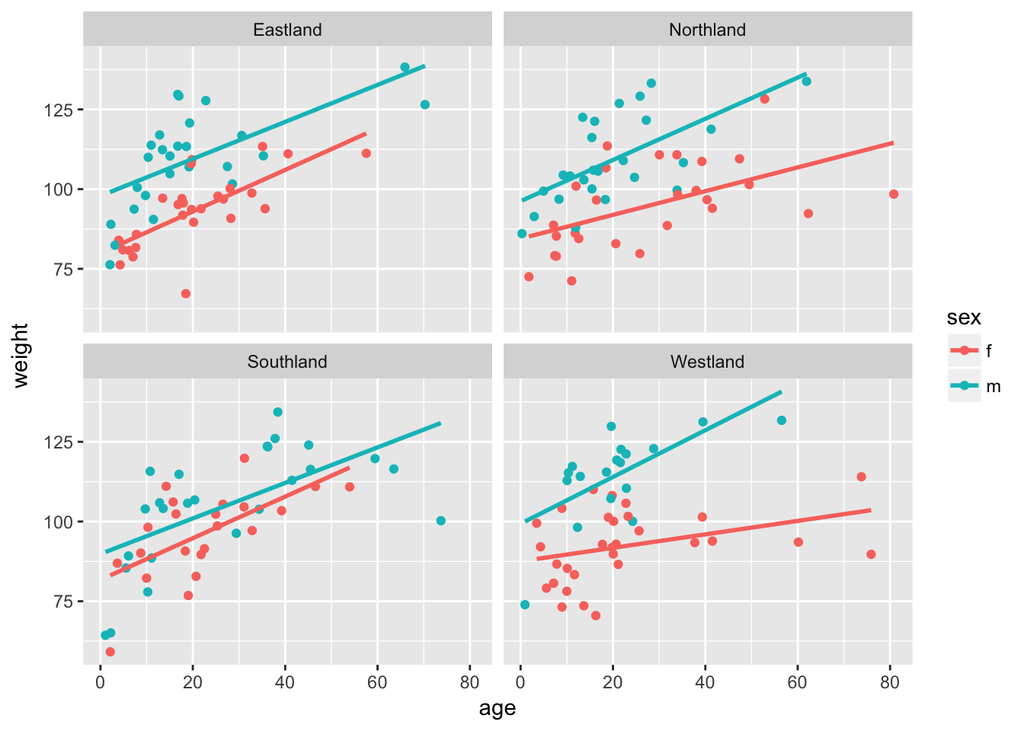

```r
ggplot(data = alien, aes(x = age, y = weight, colour = sex)) +
  geom_point() +
  geom_smooth(method = "lm", se = FALSE) +
  facet_wrap(~region)
```

Boxplot

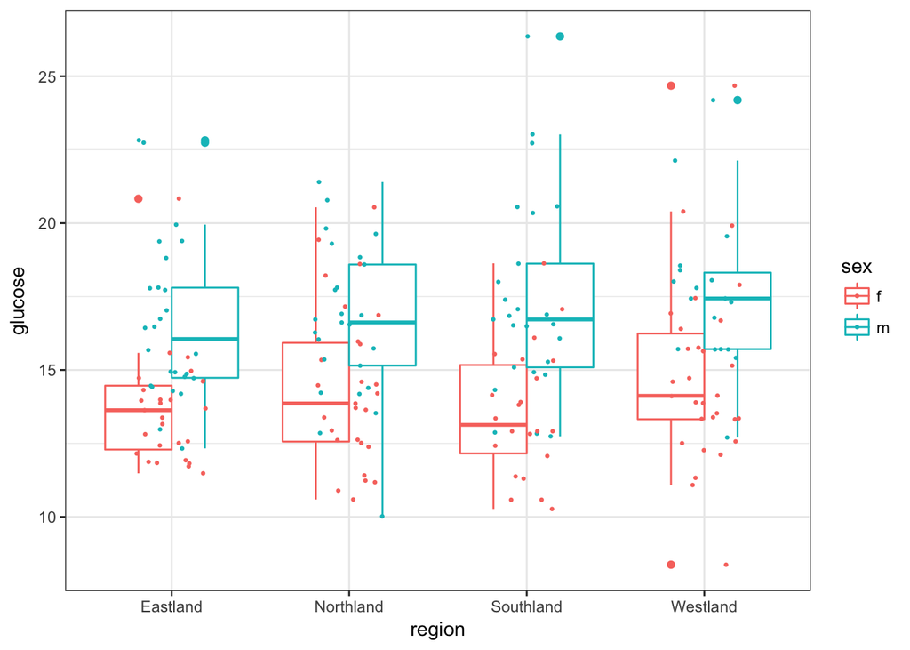

```r
ggplot(alien, aes(x= region, y = glucose, colour = sex)) +
  geom_boxplot() +
  geom_jitter(width=0.2, size=0.5) +
  theme_bw()
```

Histogram

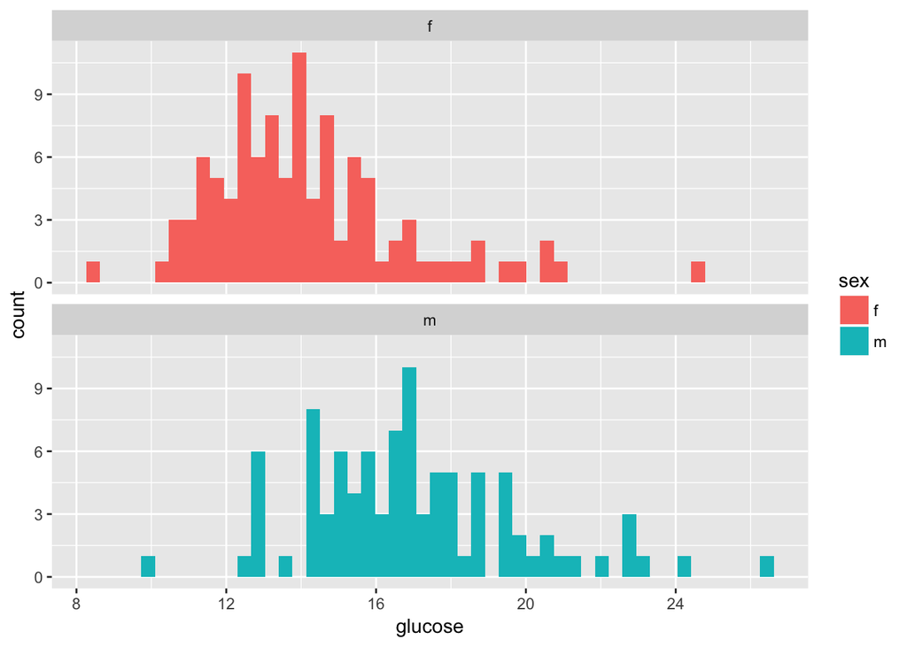

```r
ggplot(alien, aes(x = glucose, fill = sex)) +
  geom_histogram(bins = 50) +
  facet_wrap(~sex, ncol = 1)
```

Glucose level by health state

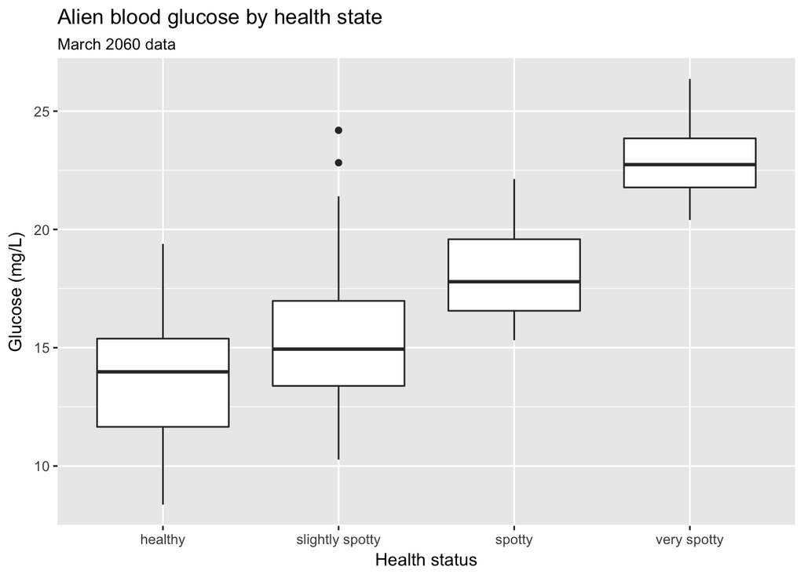

```r
ggplot(alien, aes(x = health, y = glucose)) +
  geom_boxplot() +
  labs(x = "Health status",
       y = "Glucose (mg/L)",
       title = "Alien blood glucose by health state",
       subtitle = "March 2060 data")
```

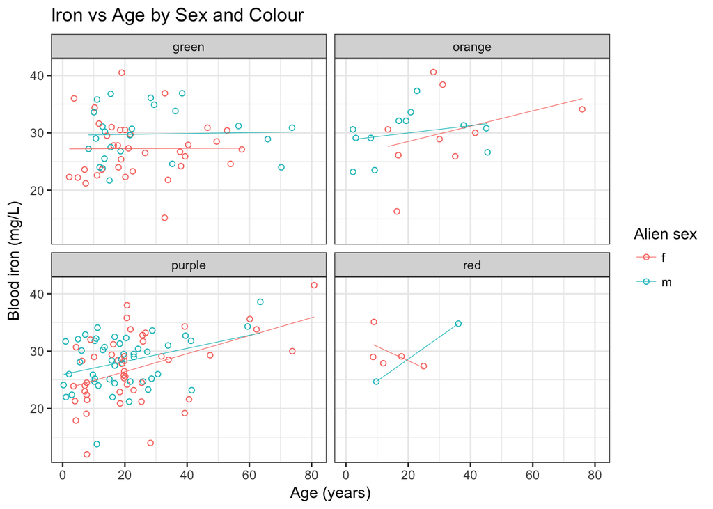

```r
ggplot(alien, aes(x = age, y = iron, colour = sex)) +
  geom_point(shape = 1) +
  geom_smooth(method = "lm", se = FALSE, size = 0.2) +
  facet_wrap(~ colour) +
  theme_bw() +
  labs(title = "Iron vs Age by Sex and Colour",
       x = "Age (years)",
       y = "Blood iron (mg/L)",
       colour = "Alien sex")
```

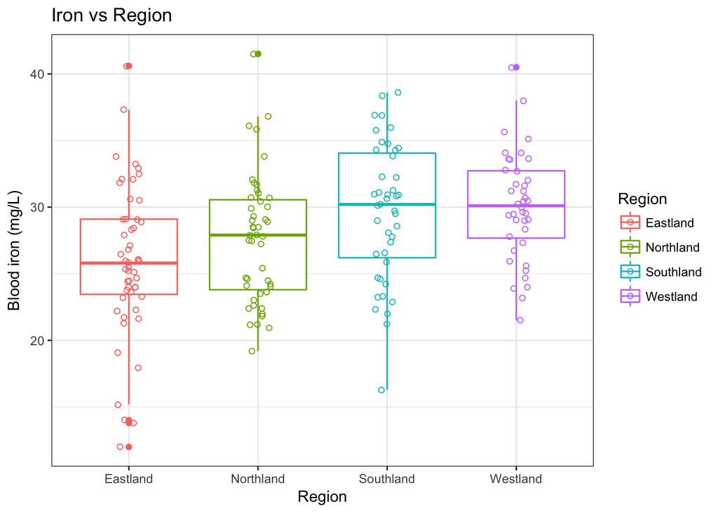

```r
ggplot(alien, aes(x = region, y = iron, colour = region)) +
  geom_boxplot() +
  geom_jitter(width = 0.1, shape = 1) +
  theme_bw() +
  labs(title = "Iron vs Region",
       x = "Region",
       y = "Blood iron (mg/L)",
       colour = "Region")
```

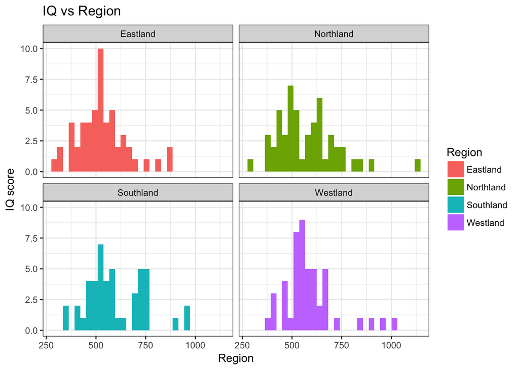

```r
ggplot(alien, aes(x = iq, fill = region)) +
  geom_histogram() +
  theme_bw() +
  facet_wrap(~ region) +
  labs(title = "IQ vs Region",
       x = "Region",
       y = "IQ score",
       fill = "Region")
```

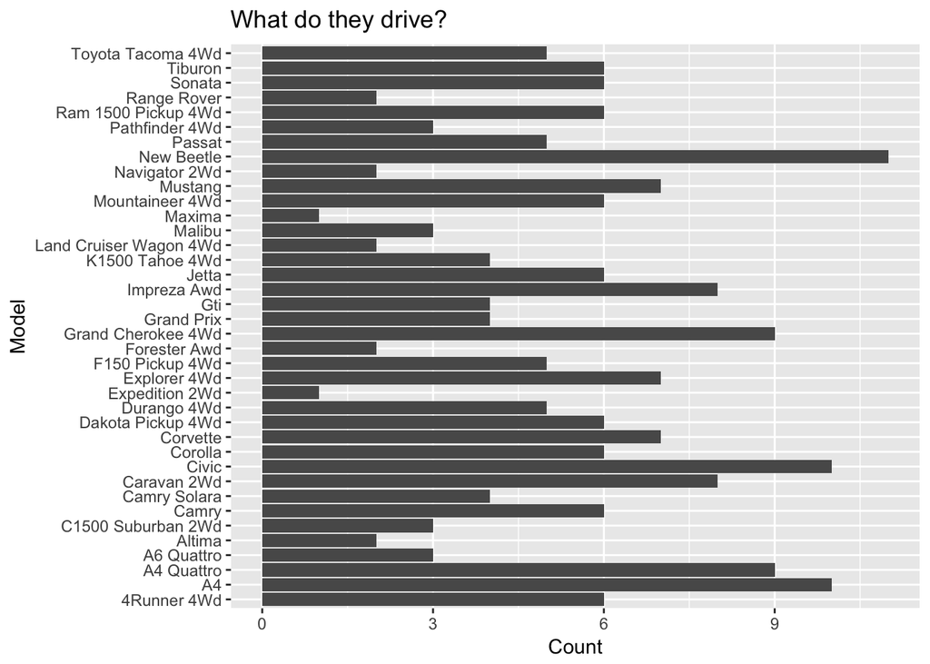

```r
ggplot(alien, aes(x = drives)) +
  geom_bar() +
  labs(title = "What do they drive?",
       x = "Model",
       y = "Count") +
  coord_flip()
```

## Stats

T test

```r
t.test(glucose ~ sex, data = alien)
```

```
##
##  Welch Two Sample t-test
##
## data:  glucose by sex
## t = -7.348, df = 189.33, p-value = 5.848e-12
## alternative hypothesis: true difference in means is not equal to 0
## 95 percent confidence interval:
##  -3.597884 -2.074998
## sample estimates:
## mean in group f mean in group m
##        14.14962        16.98606
```

Chi square

```r
chisq.test(alien$sex, alien$colour == "purple")
```

```
##
##  Pearson's Chi-squared test with Yates' continuity correction
##
## data:  alien$sex and alien$colour == "purple"
## X-squared = 0.79866, df = 1, p-value = 0.3715
```

## Regression

```r
mod1 <- lm(iron ~ glucose + region, data=alien)
# model summary
summary(mod1)
```

```
##
## Call:
## lm(formula = iron ~ glucose + region, data = alien)
##
## Residuals:
##      Min       1Q   Median       3Q      Max
## -13.5532  -3.3372   0.0718   2.8227  15.2440
##
## Coefficients:
##                 Estimate Std. Error t value Pr(>|t|)
## (Intercept)      20.1610     1.8716  10.772  < 2e-16 ***
## glucose           0.3811     0.1161   3.282 0.001241 **
## regionNorthland   1.5295     0.9836   1.555 0.121768
## regionSouthland   3.5558     1.0075   3.529 0.000532 ***
## regionWestland    3.8758     1.0301   3.762 0.000229 ***
## ---
## Signif. codes:  0 '***' 0.001 '**' 0.01 '*' 0.05 '.' 0.1 ' ' 1
##
## Residual standard error: 4.858 on 176 degrees of freedom
##   (19 observations deleted due to missingness)
## Multiple R-squared:  0.1567, Adjusted R-squared:  0.1375
## F-statistic: 8.177 on 4 and 176 DF,  p-value: 4.528e-06
```

```r
# model diagnostics
# plot(mod1)
```